# Intro to classification

## Motivation

**Question:** You’ve learned linear regression predicts continuous outcomes (salary, house prices). What if we want to predict a binary outcome like:

- Will a customer default on their loan? (Yes/No)
- Is this email spam? (Yes/No)
- Does a patient have a disease? (Yes/No)

**Why not just use linear regression?**

Think about it: What problems might arise if we try to fit a line to predict 0s and 1s?

**Today’s Goal:**

We’ll discover why classification requires different tools, and more importantly, why evaluating classification models is fundamentally different from evaluating regression models.

## Regression vs Classification

- **Regression:** predict a continuous / quantitative outcome (e.g., salary, house price).
  - Evaluation metrics we used previously: Mean Squared Error (MSE), Root Mean Squared Error (RMSE), R-squared
- **Classification:** predict a categorical outcome (e.g., default: Yes / No)

Why the distinction matters: evaluation metrics and modeling choices differ.

## Why not use linear regression?

If we naively regress the binary outcome on predictors, problems arise:

- Predictions can fall outside [0,1]
- Residuals and error distribution assumptions fail

Instead, classification approaches or probability-based methods are used; for now we focus on classification evaluation.

## The `Default` dataset

[output not shown]

[output cut: 9986 more lines]

Variables we will use:

- `default`: factor with levels `No`, `Yes` (response)
- `balance`: monthly credit card balance (predictor)
- `income`: annual income (predictor)
- `student`: Yes/No (qualitative predictor)

## Balance vs Income scatter plot by default

- What patterns do you notice?

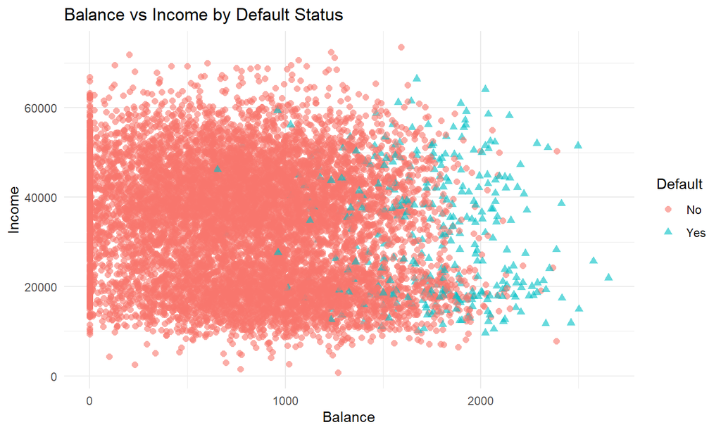

## Class distribution

```r
Default %>%
  count(default) %>%
  mutate(pct = n / sum(n))
```

```
##   default    n    pct
## 1      No 9667 0.9667
## 2     Yes  333 0.0333
```

Note: this dataset is imbalanced – only a small fraction of observations default.

- Can be a common isue with classification data

## Boxplot: balance by default

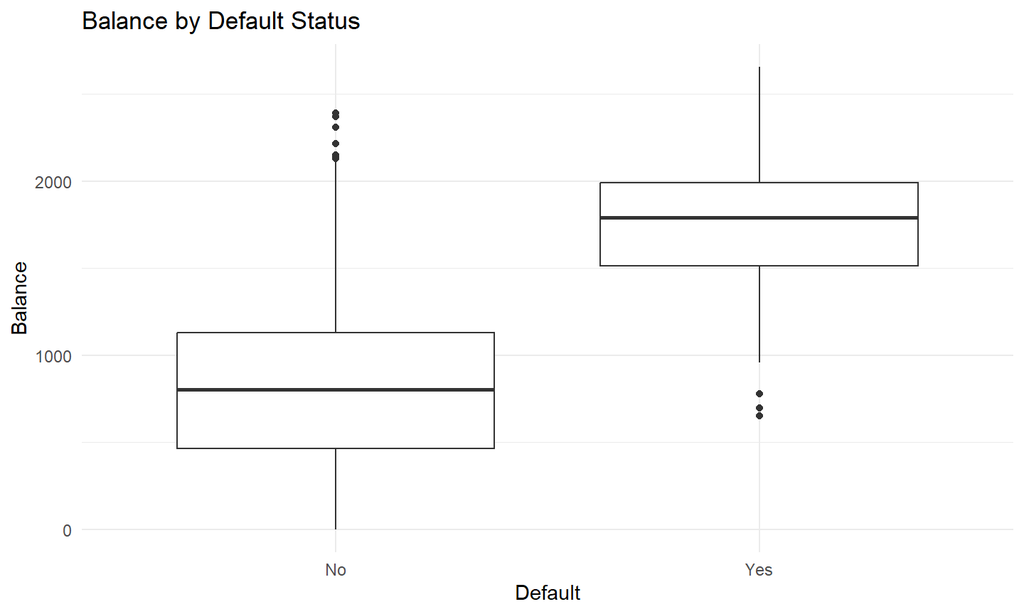

Observation: defaulting customers tend to have higher balances on average.

## Classification goal

Given features (balance, income, student), assign each customer to `Yes` or `No` for default.

Two broad pieces:

1. A rule (classifier) that maps features to a predicted class.
   - Given the class imbalance in our dataset, what would be a decent prediction?
2. An evaluation scheme to quantify how good the rule is.

## Baseline (naive) classifier

- A simple baseline: **always predict `No`** (i.e., assume nobody defaults).
- This is a useful sanity-check for any classifier on imbalanced data.

We’ll compute metrics for this baseline.

## Introduction to Confusion Matrix

For binary classification (positive = `Yes` default) there are four different possibilities:

|  | Predicted Yes | Predicted No |
| --- | --- | --- |
| Actual Yes | True Positive (TP) | False Negative (FN) |
| Actual No | False Positive (FP) | True Negative (TN) |

- Confusion matrix summarizes correct and incorrect predictions and are the basis for our performance metrics.

## Compute confusion matrix with dplyr

```r
# Actual truth
truth <- Default$default
# Our naive prediction of no default for all
Default <- Default %>% mutate(pred_baseline = factor("No", levels = levels(default)))
# Use table for confusion matrix
table(Actual = Default$default, Predicted = Default$pred_baseline)
```

```
##       Predicted
## Actual   No  Yes
##    No  9667    0
##    Yes  333    0
```

**Question:** What are the TP, FP, TN, FN values in this confusion matrix?

- **True Positive (TP):** Correctly predicting a customer will default (helps us avoid bad loans).
- **False Positive (FP):** Predicting default when the customer would have paid (lost business opportunity).
- **True Negative (TN):** Correctly predicting no default (safe loans granted).
- **False Negative (FN):** Predicting no default when the customer actually defaults (a missed risky case).

For loan business, need to figure out how aggressive we want to be

## Accuracy and Error Rate

**Definition:** Accuracy measures the overall proportion of correct predictions, while Error Rate measures the proportion of incorrect predictions.

**Formulas:**  
- Accuracy = (TP + TN) / (TP + TN + FP + FN)  
- Error Rate = (FP + FN) / (TP + TN + FP + FN)

```r
Default %>%
  summarise(
    accuracy = mean(pred_baseline == default),
    error_rate = 1 - mean(pred_baseline == default)
  )
```

```
##   accuracy error_rate
## 1   0.9667     0.0333
```

## Precision

**Definition:** Precision (positive predictive value) is the fraction of predicted Yes cases that are actually Yes. High precision means few false positives.

**Formula:** Precision = TP / (TP + FP)

```r
Default %>%
  summarise(
    precision = sum(pred_baseline == "Yes" & default == "Yes") /
                sum(pred_baseline == "Yes")
  )
```

```
##   precision
## 1       NaN
```

## Recall

**Definition:** Recall (sensitivity) is the fraction of actual Yes cases that are correctly predicted. High recall means few false negatives.

**Formula:** Recall = TP / (TP + FN)

```r
Default %>%
  summarise(
    recall = sum(pred_baseline == "Yes" & default == "Yes") /
             sum(default == "Yes")
  )
```

```
##   recall
## 1      0
```

## Specificity

**Definition:** Specificity is the fraction of actual No cases that are correctly predicted as No. High specificity means few false positives.

**Formula:** Specificity = TN / (TN + FP)

```r
Default %>%
  summarise(
    specificity = sum(pred_baseline == "No" & default == "No") /
                  sum(default == "No")
  )
```

```
##   specificity
## 1           1
```

## Summary of Performance Metrics

```r
Default %>% summarise(
  Accuracy = mean(pred_baseline == default),
  Error_Rate = 1 - mean(pred_baseline == default),
  Precision = sum(pred_baseline == "Yes" & default == "Yes") / sum(pred_baseline == "Yes"),
  Recall = sum(pred_baseline == "Yes" & default == "Yes") / sum(default == "Yes"),
  Specificity = sum(pred_baseline == "No" & default == "No") / sum(default == "No")
)
```

```
##   Accuracy Error_Rate Precision Recall Specificity
## 1   0.9667     0.0333       NaN      0           1
```

- Accuracy looks good but `NaN` Precision and 0 Recall should raise red flags
- What is the main risk here?

## Simple rule-based classifier

- Our earlier analysis showed high balance loans tend to default.
- Predict `Yes` if `balance > 2000`, else `No`. Compare its metrics to the naive classifier.

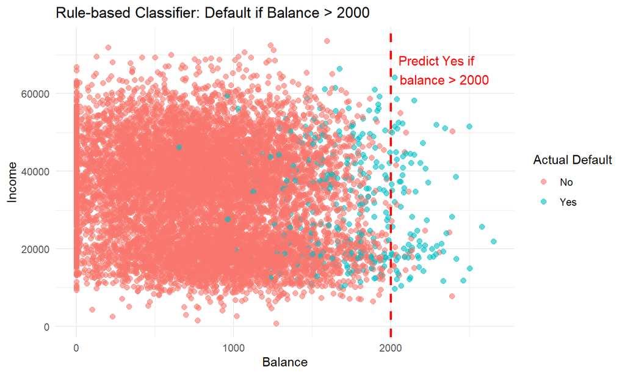

## Metrics comparison

| Metric | Baseline (Always ‘No’) | Rule (Balance > 2000) |
| --- | --- | --- |
| Accuracy | 0.967 | 0.972 |
| Precision | NaN | 0.764 |
| Recall | 0.000 | 0.243 |
| Specificity | 1.000 | 0.997 |

- **Accuracy increased slightly** - both models have high accuracy (96.7% → 97.2%), but this masks important differences
- **Precision & Recall:** Baseline can’t identify *any* defaulters (NaN precision, 0% recall)
- **Rule-based classifier:** Now catches some defaulters! Much better recall.
- **Trade-off:** Slightly lower specificity means we’re rejecting some good customers

**Bottom line:** The simple rule is far more useful than the naive baseline, even though accuracy alone doesn’t show this clearly.

## Imbalanced classes: why accuracy can mislead

Because only a small percent default, a classifier that predicts `No` for everyone attains high accuracy but is useless for catching defaulters.

Hence alternative metrics (precision, recall, specificity) are crucial.

## F1 Score and Balanced Accuracy

- **Balanced accuracy** = Average of how well we predict each class separately
  - Regular accuracy can be high just by getting the majority class right
  - Balanced accuracy = (Recall + Specificity) / 2
  - Treats both classes (Yes and No) as equally important
- **F1 score** = harmonic mean of Precision and Recall; balances false positives and false negatives.
  - 2 * Precision * Recall / (Precision + Recall)

| Metric | Baseline (Always ‘No’) | Rule (Balance > 2000) |
| --- | --- | --- |
| Accuracy | 0.967 | 0.972 |
| Balanced Accuracy | 0.500 | 0.620 |
| F1 Score | 0.000 | 0.369 |

**Key Insights:**

- Balanced accuracy reveals the naive classifier performs at chance (50%) for detecting defaulters
- F1 score of 0 (or NaN) for baseline is a major red flag - it catches no positives
- Rule-based classifier shows meaningful improvement on both metrics

## Wrap-up / Key takeaways

- Classification predicts categorical outcomes – evaluation must focus on class-specific performance.
- **Confusion matrices** make trade-offs explicit (TP, FP, TN, FN).
- **Accuracy** can be misleading on imbalanced datasets; examine **precision**, **recall**, **specificity**, and **F1**.
- Simple rule-based classifiers can illustrate trade-offs before moving to probabilistic models (e.g., logistic regression) or more complex learners.